# Визуализация биомедицинских данных, домашнее задание №1

Наталья Шейко

##### 1. Загрузите датасет insurance_cost.csv.

```r
library(ggplot2)
library(dplyr)
library(ggpubr)
data = read.csv('insurance_cost.csv', stringsAsFactors = T)
head(data, 5)
```

```
##   age    sex    bmi children smoker    region   charges
## 1  19 female 27.900        0    yes southwest 16884.924
## 2  18   male 33.770        1     no southeast  1725.552
## 3  28   male 33.000        3     no southeast  4449.462
## 4  33   male 22.705        0     no northwest 21984.471
## 5  32   male 28.880        0     no northwest  3866.855
```

```r
str(data)
```

```
## 'data.frame':    1338 obs. of  7 variables:
##  $ age     : int  19 18 28 33 32 31 46 37 37 60 ...
##  $ sex     : Factor w/ 2 levels "female","male": 1 2 2 2 2 1 1 1 2 1 ...
##  $ bmi     : num  27.9 33.8 33 22.7 28.9 ...
##  $ children: int  0 1 3 0 0 0 1 3 2 0 ...
##  $ smoker  : Factor w/ 2 levels "no","yes": 2 1 1 1 1 1 1 1 1 1 ...
##  $ region  : Factor w/ 4 levels "northeast","northwest",..: 4 3 3 2 2 3 3 2 1 2 ...
##  $ charges : num  16885 1726 4449 21984 3867 ...
```

##### 2. Выведите гистограммы всех нумерических переменных.

```r
names_num <- data %>% select(where(is.numeric)) %>% colnames() %>% print()
```

```
## [1] "age"      "bmi"      "children" "charges"
```

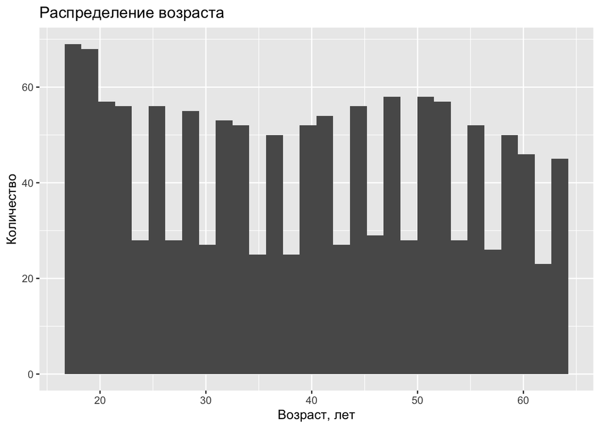

```r
ggplot() +
  geom_histogram(aes(x = data$age)) +
  ggtitle('Распределение возраста') +
  labs(x = 'Возраст, лет', y = 'Количество')
```

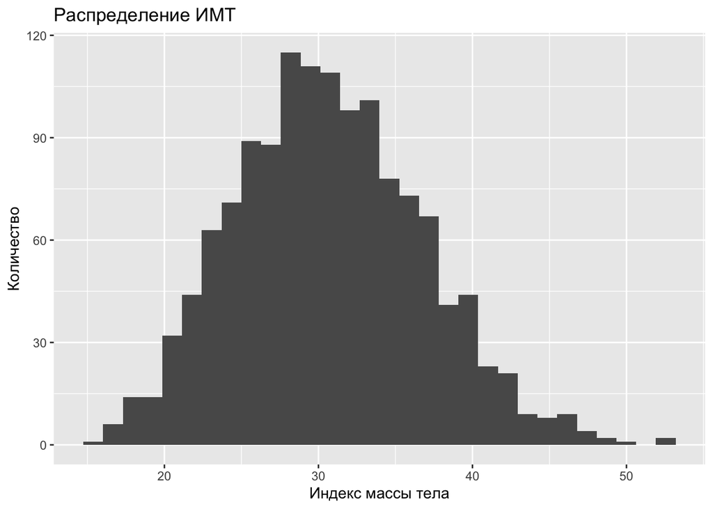

```r
ggplot() +
  geom_histogram(aes(x = data$bmi)) +
  ggtitle('Распределение ИМТ') +
  labs(x = 'Индекс массы тела', y = 'Количество')
```

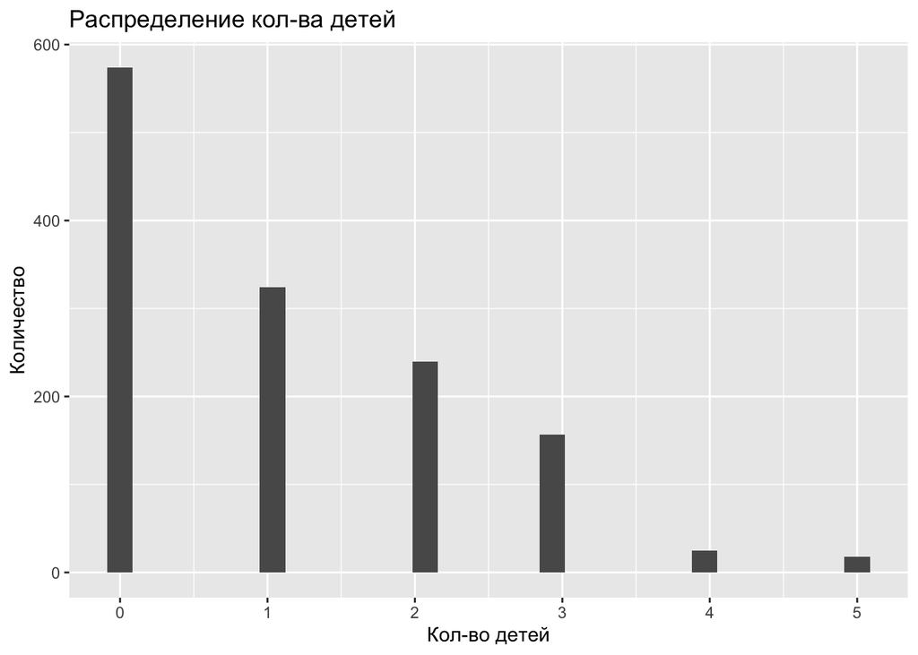

```r
ggplot() +
  geom_histogram(aes(x = data$children)) +
  ggtitle('Распределение кол-ва детей') +
  labs(x = 'Кол-во детей', y = 'Количество')
```

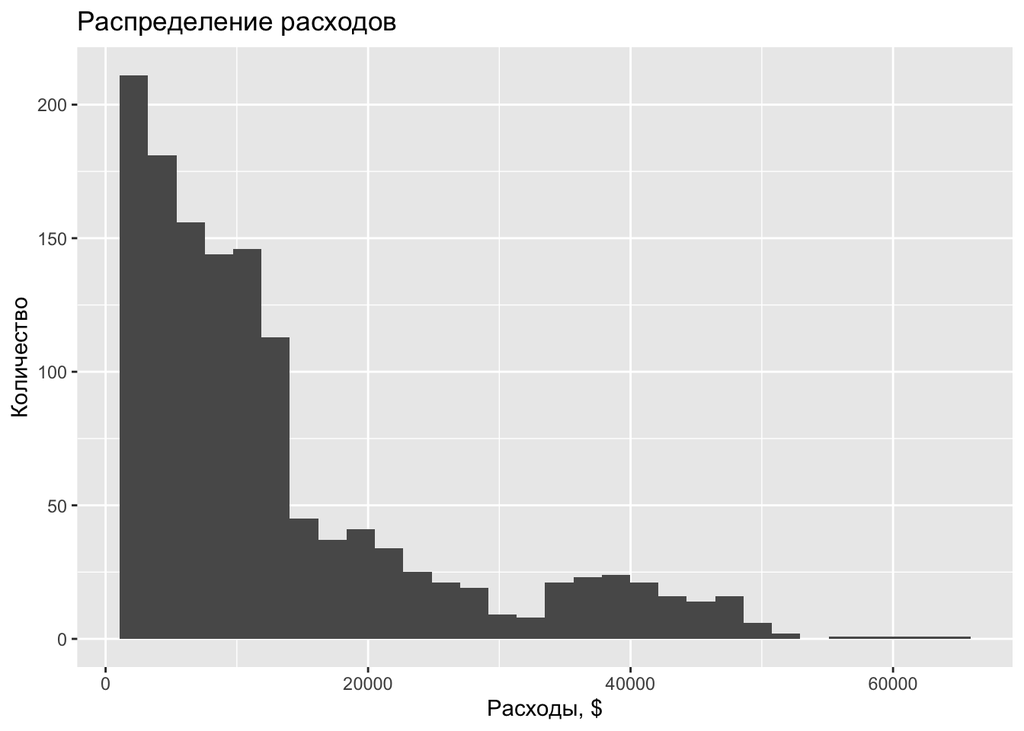

```r
ggplot() +
  geom_histogram(aes(x = data$charges)) +
  ggtitle('Распределение расходов') +
  labs(x = 'Расходы, $', y = 'Количество')
```

##### 3. Нарисуйте график плотности по колонке charges. Отметьте вертикальные линии средней и медианы на графике. Раскрасьте текст и линии средней и медианы разными цветами. Добавьте текстовые пояснения значения средней и медианы. Подберите тему для графика. Назовите оси.

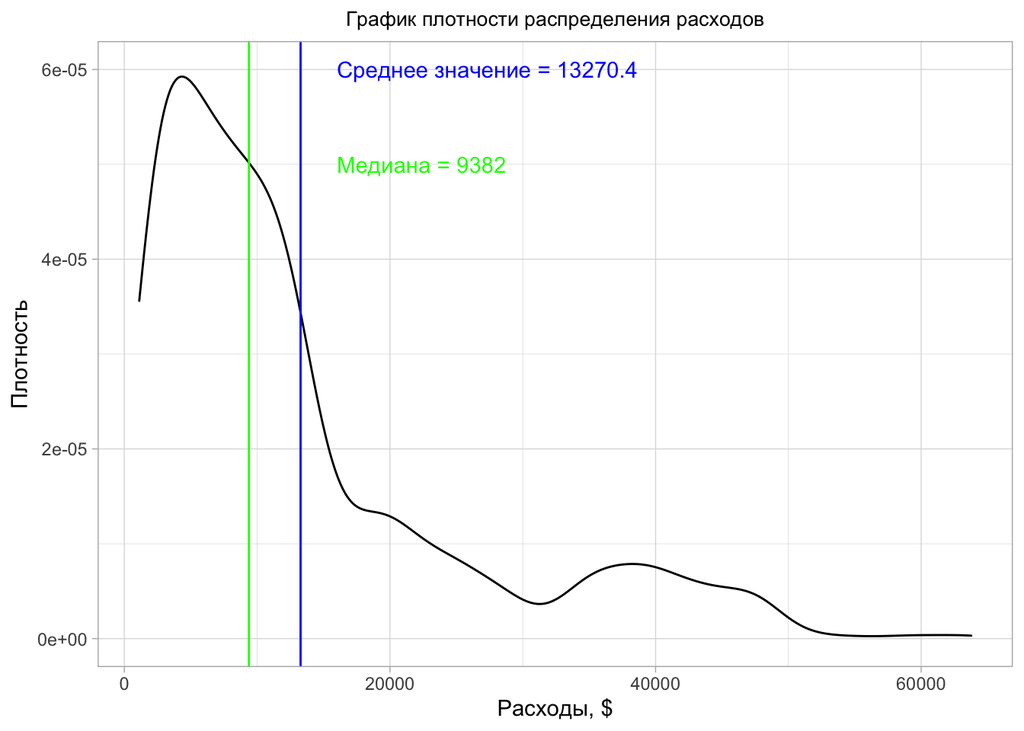

```r
charges_mean <- mean(data$charges)
charges_median <-  median(data$charges)

charges_density <-
ggplot(data = data,
       aes(x = charges)) +
  geom_density() +
  theme_light() +
  geom_vline(aes(xintercept = charges_mean), color = 'blue') +
  geom_vline(aes(xintercept = charges_median), color = 'green') +
  annotate("text",
           x= 16000, y=0.00006,
           label=paste0("Среднее значение = ", round(charges_mean, 1)),
           color = 'blue', hjust = 0) +
  annotate("text",
           x= 16000, y=0.00005,
           label=paste0("Медиана = ", round(charges_median, 1)),
           color = 'green', hjust = 0)+
  ggtitle('График плотности распределения расходов') +
  theme(plot.title = element_text(hjust = 0.5, size = 10)) +
  labs(x = 'Расходы, $', y = 'Плотность')

charges_density
```

##### 4. Сделайте три box_plot по отношению переменных charges и (1) sex (2) smoker (3) region. Подберите тему для графика. Назовите оси.

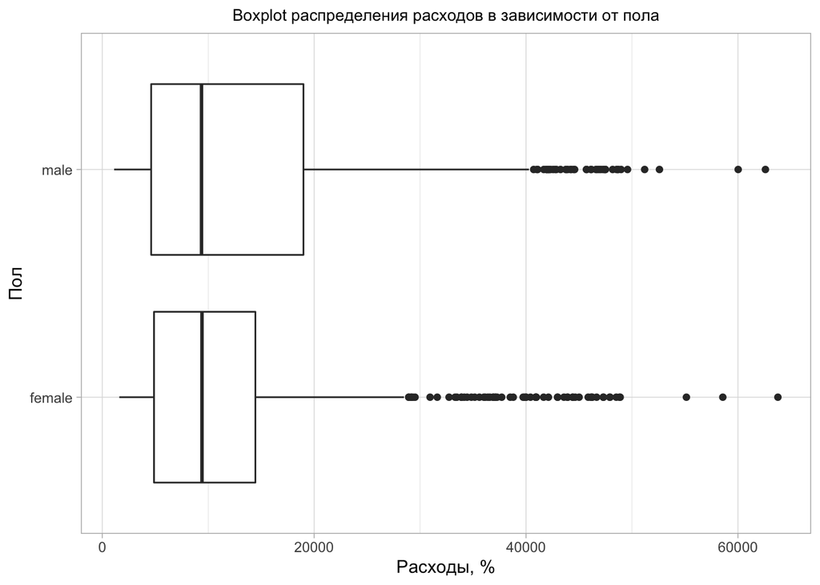

```r
charges_vs_sex <-
ggplot() +
  geom_boxplot(data = data,
               aes(x = charges, y = sex)) +
  theme_light() +
  ggtitle('Boxplot распределения расходов в зависимости от пола') +
  labs(x = 'Расходы, %', y = 'Пол') +
  theme(plot.title = element_text(hjust = 0.5, size = 10))

charges_vs_smoker <-
ggplot() +
  geom_boxplot(data = data,
               aes(x = charges, y = smoker)) +
  theme_light() +
  ggtitle('Boxplot распределения расходов в зависимости от статуса курения') +
  labs(x = 'Расходы, %', y = 'Статус курения') +
  theme(plot.title = element_text(hjust = 0.5, size = 10))

charges_vs_region <-
ggplot() +
  geom_boxplot(data = data,
               aes(x = charges, y = region)) +
  theme_light() +
  ggtitle('Boxplot распределения расходов в зависимости от региона') +
  labs(x = 'Расходы, %', y = 'Регионы') +
  theme(plot.title = element_text(hjust = 0.5, size = 10))

charges_vs_sex
```

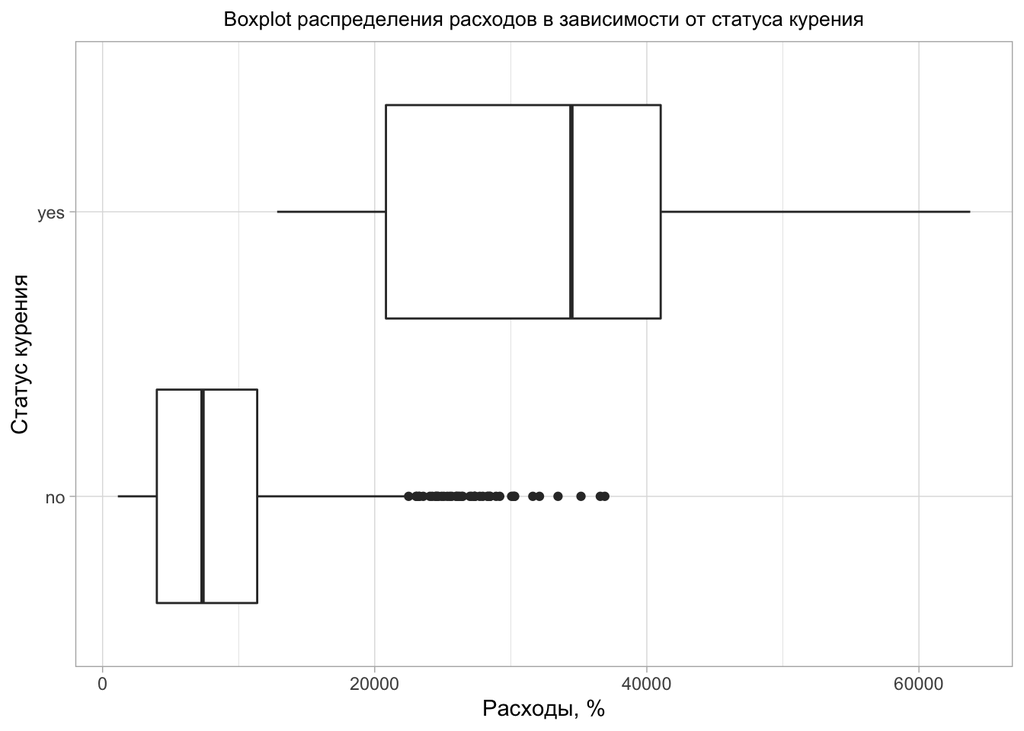

```r
charges_vs_smoker
```

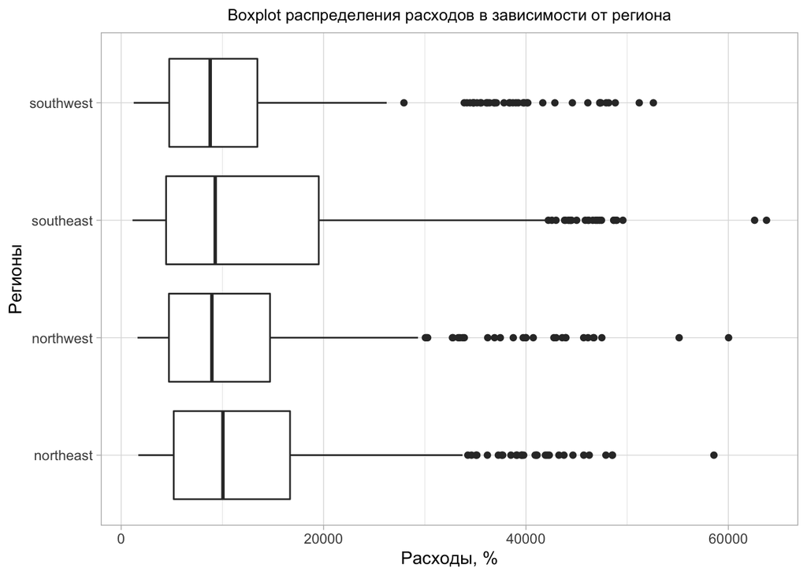

```r
charges_vs_region
```

##### 5. Объедините графики из заданий 3 и 4 в один так, чтобы сверху шёл один график из задания 3, а под ним 3 графика из задания 4. Сделайте общее название для графика.

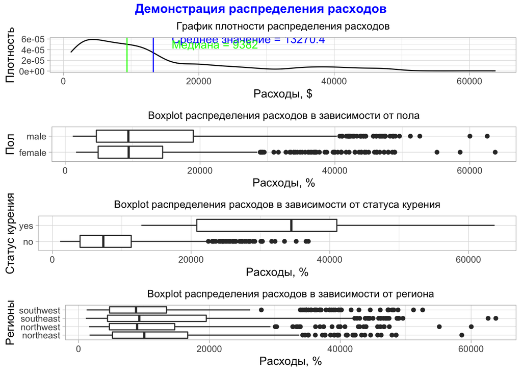

```r
charges_combine_plot <-
  annotate_figure(ggarrange(charges_density, charges_vs_sex,
                            charges_vs_smoker, charges_vs_region,
                            ncol = 1, nrow = 4),
                  top = text_grob("Демонстрация распределения расходов",
                                  color = "blue", face = "bold"))
charges_combine_plot
```

##### 6. Сделайте фасет графика из задания 3 по колонке region.

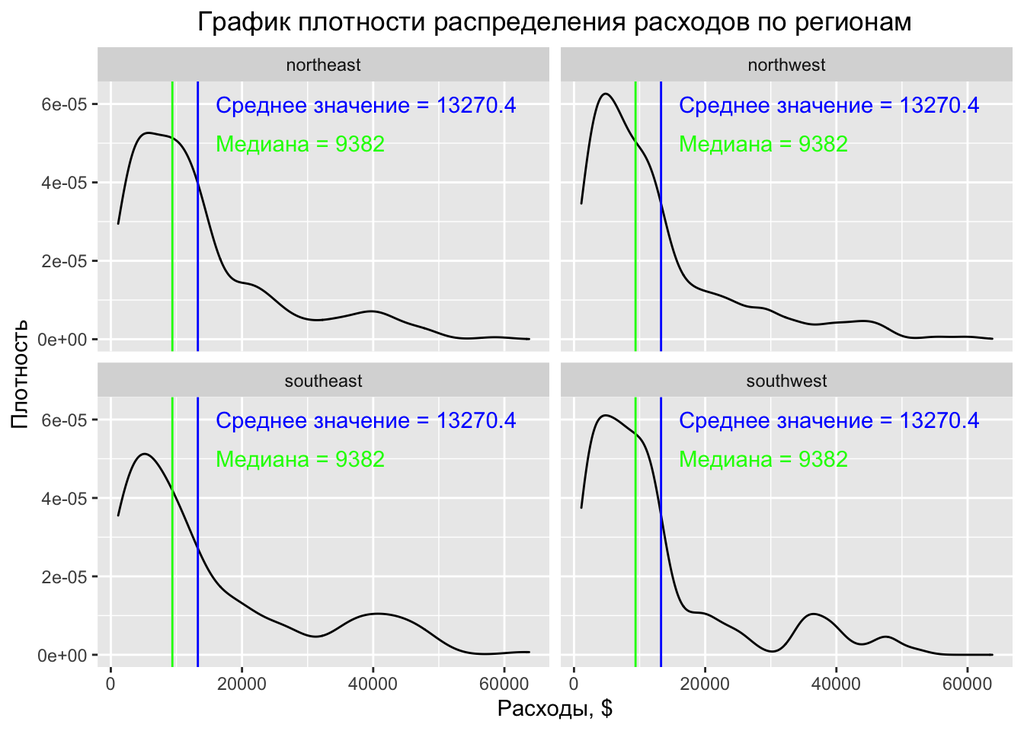

```r
ggplot(data = data,
       aes(x = charges, group = region)) +
  geom_density() +
  geom_vline(aes(xintercept = charges_mean), color = 'blue') +
  geom_vline(aes(xintercept = charges_median), color = 'green') +
  annotate("text",
           x= 16000, y=0.00006,
           label=paste0("Среднее значение = ", round(charges_mean, 1)),
           color = 'blue', hjust = 0) +
  annotate("text",
           x= 16000, y=0.00005,
           label=paste0("Медиана = ", round(charges_median, 1)),
           color = 'green', hjust = 0)+
  ggtitle('График плотности распределения расходов по регионам') +
  theme(plot.title = element_text(hjust = 0.5)) +
  labs(x = 'Расходы, $', y = 'Плотность') +
  facet_wrap(. ~ region)
```

##### 7. Постройте scatter plot отношения переменных age и charges. Добавьте названия осей, название графика и тему. Сделайте так, чтобы числа по оси Х отображались 14 шрифтом.

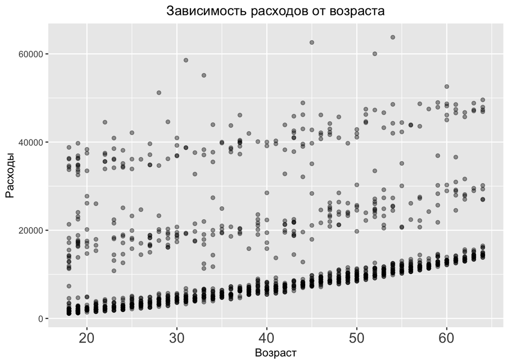

```r
data %>%
  ggplot() +
  geom_point(aes(x = age, y = charges), alpha = 0.4) +
  theme_grey() +
  ggtitle('Зависимость расходов от возраста') +
  theme(plot.title = element_text(hjust = 0.5),
        axis.text.x= element_text(size = 14)) +
  labs(x = 'Возраст', y = 'Расходы')
```

##### 8. Проведите линию тренда для предыдущего графика.

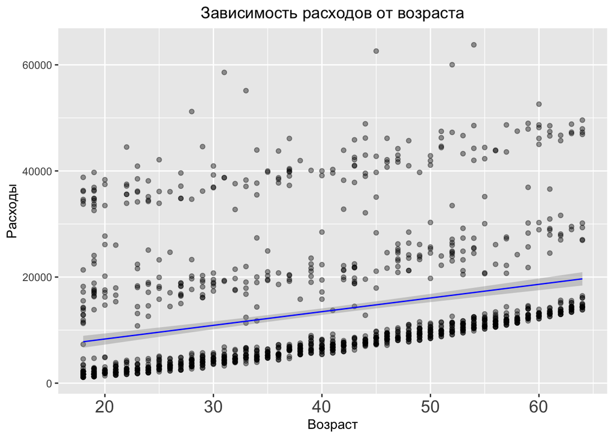

```r
data %>%
  ggplot(aes(x = age, y = charges)) +
  geom_point(alpha = 0.4) +
  theme_grey() +
  ggtitle('Зависимость расходов от возраста') +
  theme(plot.title = element_text(hjust = 0.5),
        axis.text.x= element_text(size = 14)) +
  labs(x = 'Возраст', y = 'Расходы') +
  geom_smooth(method=lm,
              color="blue", size = 0.5,
              se=TRUE)
```

##### 9. Сделайте разбивку предыдущего графика по колонке smokers (у вас должно получится две линии тренда для курящих и нет).

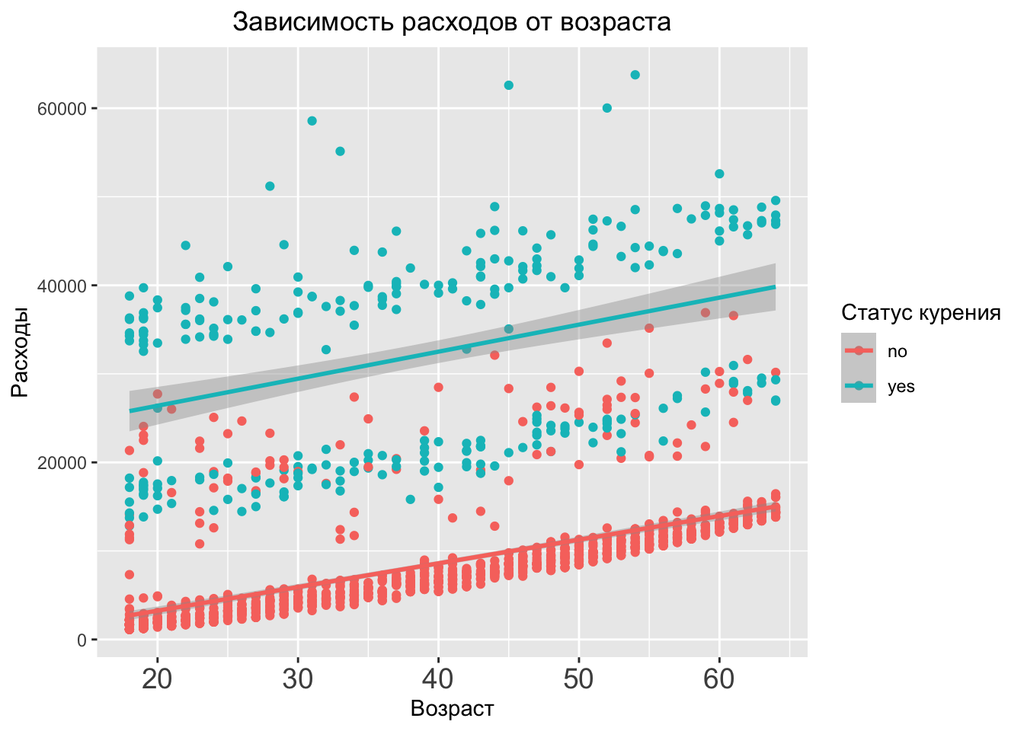

```r
data %>%
  ggplot(aes(x = age, y = charges, colour = smoker)) +
  geom_point() +
  theme_grey() +
  ggtitle('Зависимость расходов от возраста') +
  theme(plot.title = element_text(hjust = 0.5),
        axis.text.x= element_text(size = 14)) +
  labs(x = 'Возраст', y = 'Расходы', colour = 'Статус курения') +
  geom_smooth(method=lm, se=TRUE)
```

##### 10. Сделайте график из заданий 7-9, но вместо переменной age используйте переменную bmi.

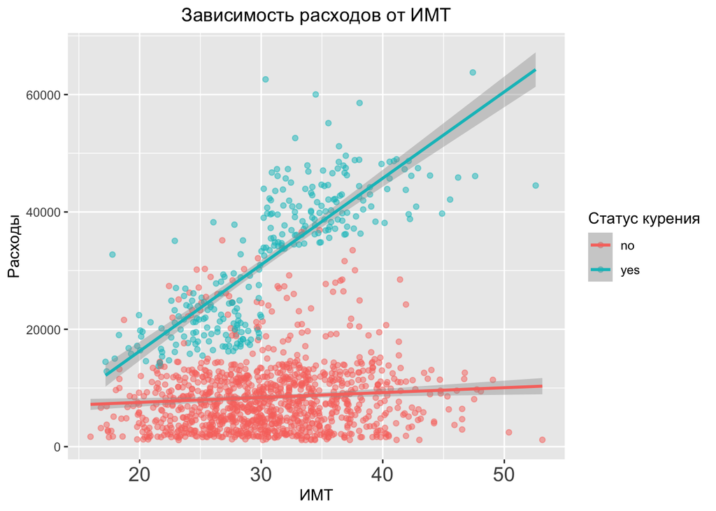

```r
data %>%
  ggplot(aes(x = bmi, y = charges, colour = smoker)) +
  geom_point(alpha = 0.5) +
  theme_grey() +
  ggtitle('Зависимость расходов от ИМТ') +
  theme(plot.title = element_text(hjust = 0.5),
        axis.text.x= element_text(size = 14)) +
  labs(x = 'ИМТ', y = 'Расходы', colour = 'Статус курения') +
  geom_smooth(method=lm, se=TRUE)
```

##### 11. Вопрос к данным №1: **Как соотносятся между собой семьи с одинаковым количеством детей в разных регионах?**

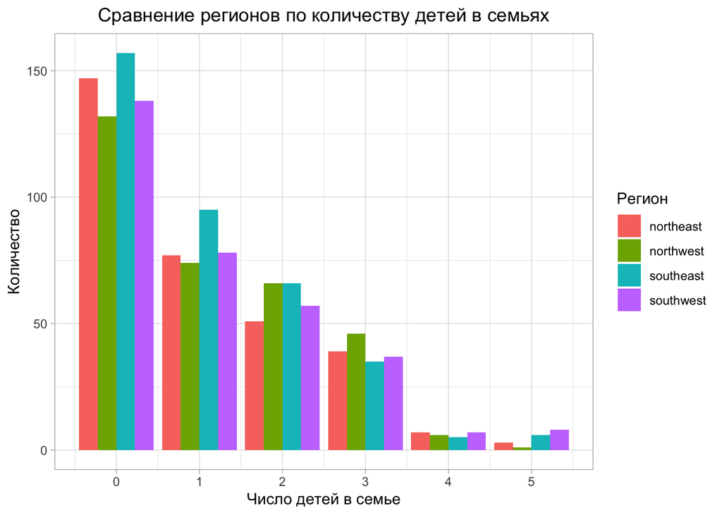

```r
data %>%
  ggplot() +
  geom_bar(data = data,
           aes(x = children, fill = region),
           position="dodge") +
  theme_light() +
  ggtitle('Сравнение регионов по количеству детей в семьях') +
  labs(x = 'Число детей в семье', y = 'Количество', fill = 'Регион') +
  theme(plot.title = element_text(hjust = 0.5)) +
  scale_x_continuous(breaks=seq(0,max(data$children),1))
```

##### 12. Вопрос к данным №2. **Как соотносятся между собой траты на одного члена семьи у курящих и некурящих родителей?**

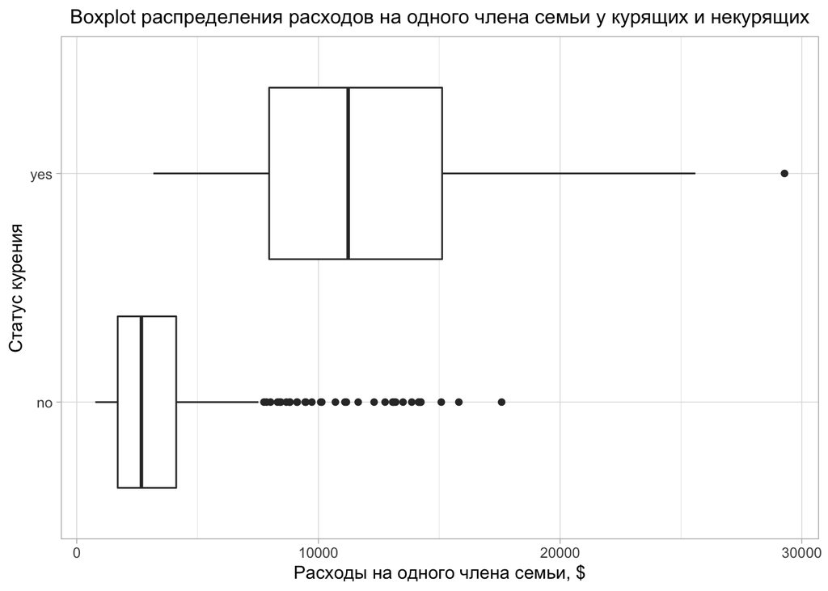

```r
# Создадим условную и почти лишенную смысла переменную  "Траты на одного члена семьи" (family_index). Для этого
# разделим траты на количество детей в семье +1 человека (поправка на родителя). Чтобы избежать деления на ноль,
# для бездетных в этом столбце проставим просто '0'. Отфильтруем только интересующие нас данные - семьи с одним
# ребенком и более.

data$family_index <- as.numeric(ifelse(data$children > 0,
                                       data$charges / (data$children +1), '0'))

data %>%
  filter(family_index > 0 ) %>%
  ggplot(aes(x = family_index, y = smoker)) +
    geom_boxplot() +
  theme_light() +
  ggtitle('Boxplot распределения расходов на одного члена семьи у курящих и некурящих') +
  theme(plot.title = element_text(hjust = 0.5, size = 12)) +
  labs(x = 'Расходы на одного члена семьи, $', y = 'Cтатус курения')
```

##### 13. Вопрос к данным №3. **Как выглядит зависимость индекса массы тела от возраста у мужчин и женщин в разбивке по статусу курения?**

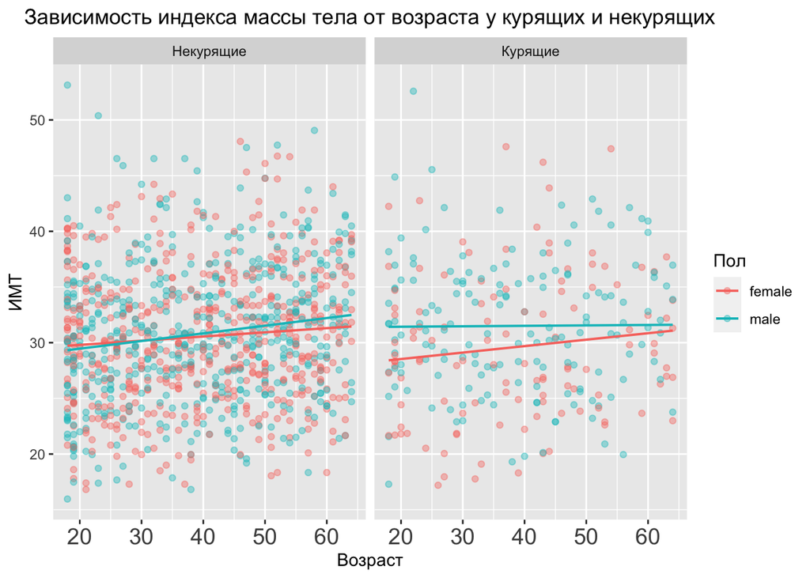

```r
data %>%
  ggplot(aes(x = age, y = bmi, color = sex)) +
  geom_point(alpha = 0.4) +
  theme_grey() +
  ggtitle('Зависимость индекса массы тела от возраста у курящих и некурящих') +
  theme(plot.title = element_text(hjust = 0.5),
        axis.text.x= element_text(size = 14)) +
  labs(x = 'Возраст', y = 'ИМТ', colour = 'Пол') +
  geom_smooth(method=lm, se=FALSE, size = 0.7, alpha = 0.5) +
  facet_grid(. ~ smoker, labeller = as_labeller(c('no' = 'Некурящие',
                                                  'yes' = 'Курящие')))
```

##### 14. Приблизительно повторить график

Ответ:

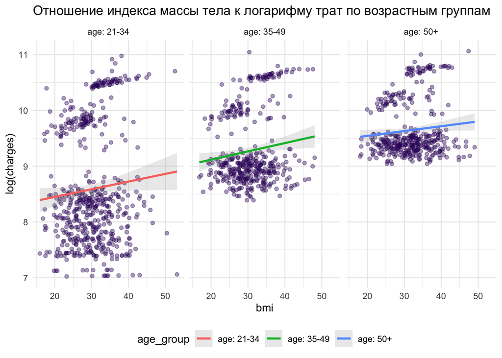

```r
data$age_group <- case_when(data$age < 35 ~ 'age: 21-34',
                            data$age > 34 & data$age < 50  ~ 'age: 35-49',
                            data$age > 49 ~ 'age: 50+')
data$log_charges <- log(data$charges)
data%>%
  ggplot(aes(x = bmi, y = log_charges, color = age_group)) +
  geom_point(alpha = 0.4, color = "#330066")+
  theme_minimal() +
  geom_smooth(method=lm, se=TRUE, alpha = 0.2) +
  facet_grid(. ~age_group) +
  theme(legend.position="bottom")+
  ggtitle('Отношение индекса массы тела к логарифму трат по возрастным группам') +
  labs(y = 'log(charges)')
```